# Part 1: Setting up the Project

# Part 4: Univariate Data Analysis

**Note**

We are going to revert back to EDA before we continue with the data preprocessing, including dealing with missing values, but we need to know information about specific variables before we can decide where to fill missing values with means or medians, drop them completely, or even scale the data. Therefore, we will conduct univariate data analysis on each variable before deciding how to deal with how we continue to preprocess the data.

```python
def histogram_boxplot(data, xlabel=None, title=None, font_scale=2, figsize=(15,7), bins=None):
    mean = np.mean(data)

    sns.set(font_scale=font_scale) # setting the font scale of the seaborn
    f2, (ax_box2, ax_hist2) = plt.subplots(2, sharex=True, gridspec_kw={"height_ratios": (.25, .75)}, figsize=figsize)
    sns.boxplot(data, ax=ax_box2, showmeans=True,color="violet") #boxplot will be created and a star will indicate the mean value
    sns.distplot(data,kde=False, ax=ax_hist2, bins=bins,palette="winter") if bins else sns.distplot(data,kde=False, ax=ax_hist2, bins=None)
    ax_hist2.axvline(mean, color='g', linestyle='--') #mean will show as vertical line in the histogram
    if xlabel: ax_hist2.set(xlabel=xlabel) #xlabel
    if title: ax_box2.set(title=title) # title of the graph
    plt.show() # for plotting the graph
```

```python
def perc_on_bar(plot, feature):
    '''
    plot
    feature: categorical feature
    the function wont work if a colume is passed in hue parameter
    '''
    total = len(feature) # length of the column
    for p in ax.patches:
        percentage = '{:.1f}%'.format(100 * p.get_height()/total) # percentage of each class of the category
        x = p.get_x() + p.get_width() / 2 - 0.05 # width of the plot
        y = p.get_y() + p.get_height()           # height of the plot
        ax.annotate(percentage, (x,y), size = 20) # annotate the percentage
    plt.show() # shows the plot
```

**Name**

```python
UCD['Name'].apply(type).value_counts()
```

```
<class 'str'>    7253
Name: Name, dtype: int64
```

```python
UCD.Name.value_counts()
```

```
Maruti           1444
Hyundai          1340
Honda             743
Toyota            507
Mercedes-Benz     380
Volkswagen        374
Ford              351
Mahindra          331
BMW               312
Audi              285
Tata              228
Skoda             202
Renault           170
Chevrolet         151
Nissan            117
Land               67
Jaguar             48
Fiat               38
Mitsubishi         36
Mini               31
Volvo              28
Porsche            19
Jeep               19
Datsun             17
Force               3
ISUZU               3
Isuzu               2
Bentley             2
Lamborghini         1
OpelCorsa           1
Hindustan           1
Ambassador          1
Smart               1
Name: Name, dtype: int64
```

There appears to be two groups of Isuzu, one in sentence case and the other in caplocks. Lets combine them into a single group called Isuzu

```python
UCD.loc[UCD['Name'] == 'ISUZU']
```

|  | Name | Location | Year | Kilometers_Driven | Fuel_Type | Transmission | Owner_Type | Mileage | Engine | Power | Seats | New_Price | Price |
| --- | --- | --- | --- | --- | --- | --- | --- | --- | --- | --- | --- | --- | --- |
| 3624 | ISUZU | Coimbatore | 2018 | 20422 | Diesel | Manual | First | 12.4 | 2499.0 | 134.0 | 5.0 | NaN | 20917.0 |
| 5979 | ISUZU | Jaipur | 2017 | 25000 | Diesel | Manual | First | 12.4 | 2499.0 | 134.0 | 5.0 | NaN | 10400.0 |
| 6919 | ISUZU | Jaipur | 2017 | 290000 | Diesel | Manual | First | 12.4 | 2499.0 | 134.0 | 5.0 | NaN | NaN |

```python
UCD['Name'] = UCD['Name'].astype(str).replace('ISUZU', 'Isuzu').astype('category')
```

```python
UCD.loc[UCD['Name'] == 'Isuzu'] # lets check to see if it worked... the above three columns should have sentence case Isuzu plus the two original for a total of 5
```

|  | Name | Location | Year | Kilometers_Driven | Fuel_Type | Transmission | Owner_Type | Mileage | Engine | Power | Seats | New_Price | Price |
| --- | --- | --- | --- | --- | --- | --- | --- | --- | --- | --- | --- | --- | --- |
| 2900 | Isuzu | Jaipur | 2017 | 34429 | Diesel | Automatic | First | 13.80 | 2999.0 | 174.57 | 7.0 | 43784.0 | 26000.0 |
| 3624 | Isuzu | Coimbatore | 2018 | 20422 | Diesel | Manual | First | 12.40 | 2499.0 | 134.00 | 5.0 | NaN | 20917.0 |
| 5979 | Isuzu | Jaipur | 2017 | 25000 | Diesel | Manual | First | 12.40 | 2499.0 | 134.00 | 5.0 | NaN | 10400.0 |
| 6470 | Isuzu | Kolkata | 2016 | 45000 | Diesel | Manual | First | 12.08 | 2999.0 | 161.00 | 7.0 | NaN | NaN |
| 6919 | Isuzu | Jaipur | 2017 | 290000 | Diesel | Manual | First | 12.40 | 2499.0 | 134.00 | 5.0 | NaN | NaN |

SImilarly, Ambassador is a brand made by Hindustan Motors, so we will combine the two under Hindustan...

```python
UCD['Name'] = UCD['Name'].astype(str).replace('Ambassador', 'Hindustan').astype('category')
```

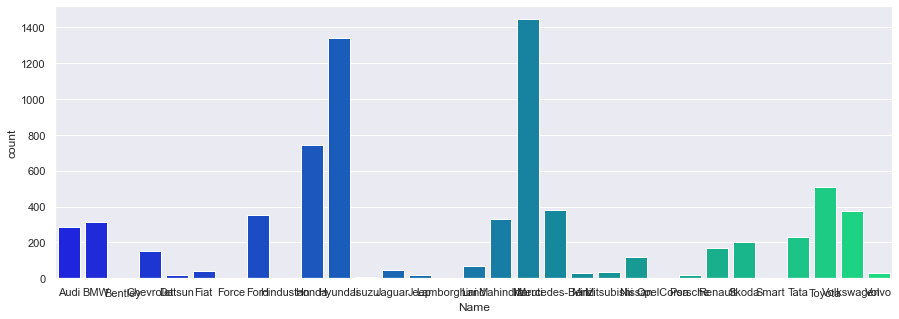

```python
plt.figure(figsize=(15,5))
ax = sns.countplot(UCD['Name'], palette='winter')
```

Two brands seem to dominate the market, with 7 other brands doing less than half of their sales. The market is then punctuated with many other brands that account for much smaller volumes of sales.

**Location**

```python
UCD['Location'].apply(type).value_counts()
```

```
<class 'str'>    7253
Name: Location, dtype: int64
```

```python
UCD.Location.value_counts()
```

```
Mumbai        949
Hyderabad     876
Coimbatore    772
Kochi         772
Pune          765
Delhi         660
Kolkata       654
Chennai       591
Jaipur        499
Bangalore     440
Ahmedabad     275
Name: Location, dtype: int64
```

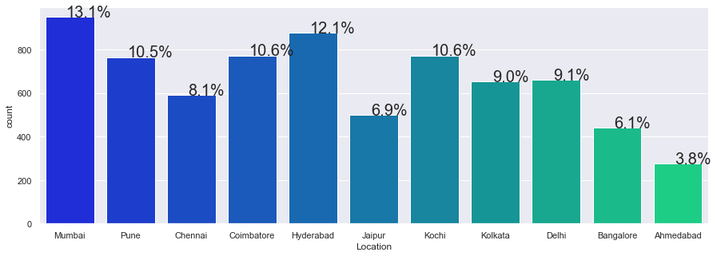

```python
plt.figure(figsize=(15,5))
ax = sns.countplot(UCD['Location'], palette='winter')
perc_on_bar(ax,UCD['Location'])
```

While not uniformly distributed, Location does not have one or two dominant players, like Name had. All eleven locations have substantial sales. It could be useful to recategorize these locations into 4 or so regions to see if the effect is regional or city specific (if at all).

**Year**

```python
UCD.Year.value_counts()
```

```
2015    929
2014    925
2016    886
2013    791
2017    709
2012    690
2011    579
2010    407
2018    361
2009    252
2008    207
2007    148
2019    119
2006     89
2005     68
2004     35
2003     20
2002     18
2001      8
2000      5
1998      4
1999      2
1996      1
Name: Year, dtype: int64
```

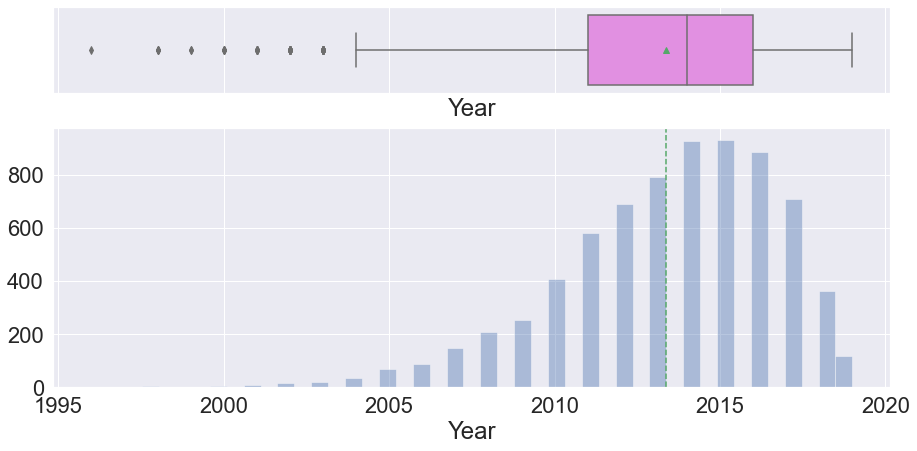

```python
histogram_boxplot(UCD['Year'])
```

- Year has a left skewed distribution. The mean is lower than the median.
- This means more used cars are from more recent years with few used cars older than 2005. This makes sense because the lifespan of a car is probably closer to 15 years or less.
- There are also fewer very recent sales. Again, this makes sense because most people do not immediately sell a brand new car

**Kilometers Driven**

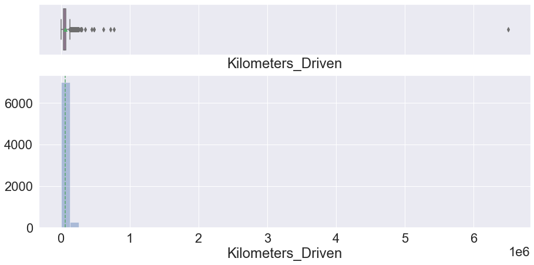

```python
histogram_boxplot(UCD['Kilometers_Driven'])
```

The graph shows that there is one or more very large outliers which is completely distorting the visuals. Before we decide to drop the outlier(s), lets find out whats going on...

```python
# This code will calculate and print the min, max and range of the variable

print('The maximum Kilometers_Driven is', UCD['Kilometers_Driven'].max(), 'km')
print('The minimum Kilometers_Driven is', UCD['Kilometers_Driven'].min(),'km')
print('The Kilometers_Driven range is', UCD['Kilometers_Driven'].max() - UCD['Kilometers_Driven'].min(), 'km')
```

```
The maximum Kilometers_Driven is 6500000 km
The minimum Kilometers_Driven is 171 km
The Kilometers_Driven range is 6499829 km
```

Apparently one vehicle was driven 6.5 million kilometers. Lets pull this vehicle to see more information about it...

```python
UCD.loc[UCD['Kilometers_Driven'] == 6500000] #select and print the row of interest
```

|  | Name | Location | Year | Kilometers_Driven | Fuel_Type | Transmission | Owner_Type | Mileage | Engine | Power | Seats | New_Price | Price |
| --- | --- | --- | --- | --- | --- | --- | --- | --- | --- | --- | --- | --- | --- |
| 2328 | BMW | Chennai | 2017 | 6500000 | Diesel | Automatic | First | 15.97 | 2993.0 | 258.0 | 5.0 | NaN | 84500.0 |

We can see there is clearly something wrong. The car is a 2017 model, which means it would have had to be driven more than 2 million km per year for the last three years. Even at a speed of 100km/h, it would over 21,000 hours per year of driving time, whereas, there are only 8760 hours in a year! The best guess is it is a typo and the car should probably only be listed at 65,000km. However, we can also check the median Kilometers_Drive for ALL cars, for ALL BMWs, for ALL 2017 models and the mean for all 2017 BMWs and try to choose the best fit. For the groups, it is imporant to check the median and not the mean because we know the outlier (6.5M) will pull the mean up but not affect the median.

```python
np.median(UCD.Kilometers_Driven) # find the median of all cars
```

```
53416.0
```

```python
np.median(UCD[UCD.Year == 2017].Kilometers_Driven) # find the median of all 2017 models
```

```
29000.0
```

```python
np.median(UCD[UCD.Name == 'BMW'].Kilometers_Driven) # find the median of all BMWs
```

```
54692.5
```

```python
# This will loop through and count only cars that are BMW and 2017, and calculate the average KM driven
counter = 0
km = 0
for index in range(0,len(UCD)): # The for loop will increase the ID value for each record

    if UCD['Name'].loc[index] == 'BMW' and UCD['Year'].loc[index] == 2017:
        counter = counter + 1
        km = km + UCD['Kilometers_Driven'].loc[index]

mean_km = ((km - 6500000))/((counter - 1))
print('There are', counter, 'BMWs from 2017 with an average Kilometers Driven of', mean_km)
```

```
There are 24 BMWs from 2017 with an average Kilometers Driven of 27743.391304347828
```

While the data set is large enough that choosing any of these values should not matter too much to the overall data, I am choice to replace the outlier with the median of 2017 cars. This seems reasonable because it is close to the mean of the 24 BMWs from 2017. We also know that a 2017 vehicle is fairly new and probably didnt have enough time to accumulate as many kms as the median of all cars or of all BMWs.

```python
UCD['Kilometers_Driven'] = UCD['Kilometers_Driven'].replace([6500000],29000) #replaces 6.5M outlier with 29,000 median
```

```python
UCD.loc[[2328], :] #check to see if it worked
```

|  | Name | Location | Year | Kilometers_Driven | Fuel_Type | Transmission | Owner_Type | Mileage | Engine | Power | Seats | New_Price | Price |
| --- | --- | --- | --- | --- | --- | --- | --- | --- | --- | --- | --- | --- | --- |
| 2328 | BMW | Chennai | 2017 | 29000 | Diesel | Automatic | First | 15.97 | 2993.0 | 258.0 | 5.0 | NaN | 84500.0 |

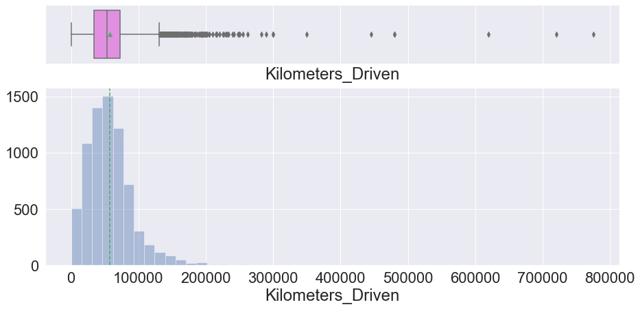

```python
histogram_boxplot(UCD['Kilometers_Driven'])
```

There are still several outliers but they appear more reasonable. Older vehicles should accumulate large kilometers. We can check to see if this logic holds by writing code that only selects rows where KM Drive >= 350,000 then creates a row at the far right which shows KM Drive divided by age of the car (2020 - Year) to see the average km driven per year...

```python
High_KM = UCD.loc[UCD['Kilometers_Driven'] >= 350000].copy() #select and print the row of interest
High_KM['KM/Y'] = High_KM['Kilometers_Driven'] / (2020 - High_KM['Year'])
High_KM
```

|  | Name | Location | Year | Kilometers_Driven | Fuel_Type | Transmission | Owner_Type | Mileage | Engine | Power | Seats | New_Price | Price | KM/Y |
| --- | --- | --- | --- | --- | --- | --- | --- | --- | --- | --- | --- | --- | --- | --- |
| 340 | Skoda | Kolkata | 2013 | 775000 | Diesel | Automatic | First | 19.30 | 1968.0 | 141.00 | 5.0 | NaN | 9750.0 | 110714.285714 |
| 358 | Hyundai | Chennai | 2009 | 620000 | Petrol | Manual | First | 20.36 | 1197.0 | 78.90 | 5.0 | NaN | 3510.0 | 56363.636364 |
| 1860 | Volkswagen | Chennai | 2013 | 720000 | Diesel | Manual | First | 20.54 | 1598.0 | 103.60 | 5.0 | NaN | 7670.0 | 102857.142857 |
| 2823 | Volkswagen | Chennai | 2015 | 480000 | Diesel | Automatic | First | 16.96 | 1968.0 | 138.03 | 5.0 | NaN | 16900.0 | 96000.000000 |
| 3092 | Honda | Kolkata | 2015 | 480000 | Petrol | Manual | First | 17.40 | 1497.0 | 117.30 | 5.0 | NaN | 6500.0 | 96000.000000 |
| 4491 | Hyundai | Bangalore | 2013 | 445000 | Petrol | Manual | First | 18.50 | 1197.0 | 82.90 | 5.0 | NaN | 5785.0 | 63571.428571 |
| 6921 | Maruti | Jaipur | 2012 | 350000 | Diesel | Manual | First | 23.40 | 1248.0 | 74.00 | 5.0 | NaN | NaN | 43750.000000 |

The values are quite high, but no vehicle on the list is exceeding much more than 100,000 km per year. If these vehicles were used as work-related vehicles (ie cabs or delivery cars) then this would be reasonable. Therefore, despite being outliers, it probably makes more sense to leave them in than to drop them or change them.

**Fuel Type**

```python
UCD['Fuel_Type'].apply(type).value_counts()
```

```
<class 'str'>    7253
Name: Fuel_Type, dtype: int64
```

```python
UCD.Fuel_Type.value_counts()
```

```
Diesel      3852
Petrol      3325
CNG           62
LPG           12
Electric       2
Name: Fuel_Type, dtype: int64
```

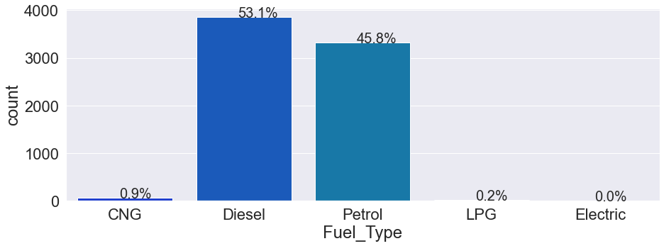

```python
plt.figure(figsize=(15,5))
ax = sns.countplot(UCD['Fuel_Type'], palette='winter')
perc_on_bar(ax,UCD['Fuel_Type'])
```

**Transmission**

```python
UCD['Transmission'].apply(type).value_counts()
```

```
<class 'str'>    7253
Name: Transmission, dtype: int64
```

```python
UCD.Transmission.value_counts()
```

```
Manual       5204
Automatic    2049
Name: Transmission, dtype: int64
```

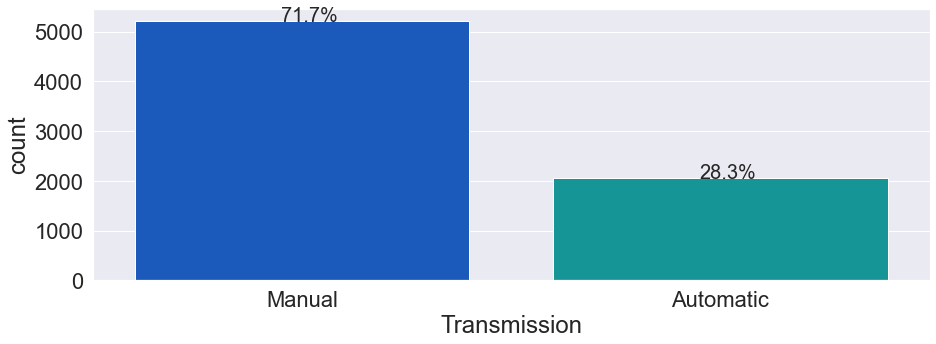

```python
plt.figure(figsize=(15,5))
ax = sns.countplot(UCD['Transmission'], palette='winter')
perc_on_bar(ax,UCD['Transmission'])
```

- It appears used cars tend to be about 2.5x more likely to be manual transmission

**Owner Type**

```python
UCD['Owner_Type'].apply(type).value_counts()
```

```
<class 'str'>    7253
Name: Owner_Type, dtype: int64
```

```python
UCD.Owner_Type.value_counts()
```

```
First             5952
Second            1152
Third              137
Fourth & Above      12
Name: Owner_Type, dtype: int64
```

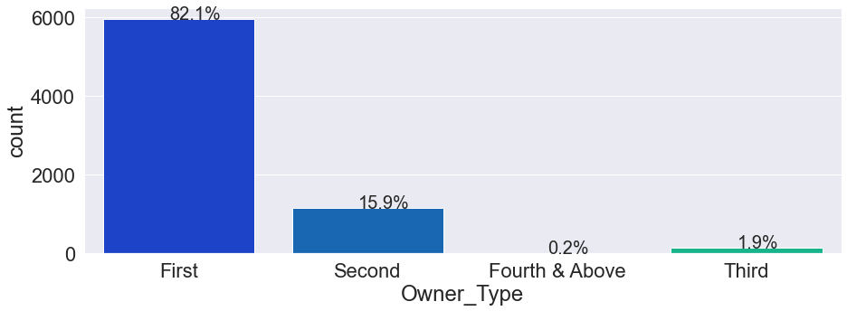

```python
plt.figure(figsize=(15,5))
ax = sns.countplot(UCD['Owner_Type'], palette='winter')
perc_on_bar(ax,UCD['Owner_Type'])
```

- A majority of used cars have had just one previous owner
- Very few have had 3 or more owners
- We could consider combining the last two bins

**Mileage**

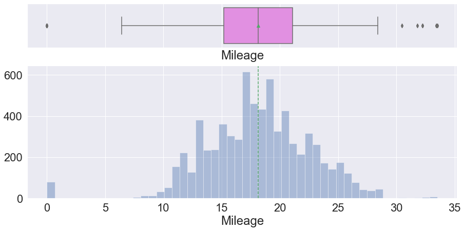

```python
histogram_boxplot(UCD['Mileage'])
```

- Mileage has almost normal distribution
- The mean and median should be approximately equal
- There are several outliers to the right and to the left

There are several instances where mileage is set to zero. Logically, this does not make sense or the car would simply not function. The distrubtion of Mileage looks almost normal, but not quite, therefore we should replace the 0 values with the column median (see next section). Mileage also has several outliers above 30. Lets take a look at both..

```python
UCD.loc[UCD['Mileage'] == 0]
```

|  | Name | Location | Year | Kilometers_Driven | Fuel_Type | Transmission | Owner_Type | Mileage | Engine | Power | Seats | New_Price | Price |
| --- | --- | --- | --- | --- | --- | --- | --- | --- | --- | --- | --- | --- | --- |
| 14 | Land | Pune | 2012 | 85000 | Diesel | Automatic | Second | 0.0 | 2179.0 | 115.0 | 5.0 | NaN | 22750.0 |
| 67 | Mercedes-Benz | Coimbatore | 2019 | 15369 | Diesel | Automatic | First | 0.0 | 1950.0 | 194.0 | 5.0 | 63882.0 | 46371.0 |
| 79 | Hyundai | Hyderabad | 2005 | 87591 | Petrol | Manual | First | 0.0 | 1086.0 | NaN | 5.0 | NaN | 1690.0 |
| 194 | Honda | Ahmedabad | 2007 | 60006 | Petrol | Manual | First | 0.0 | NaN | NaN | NaN | NaN | 3835.0 |
| 229 | Ford | Bangalore | 2015 | 70436 | Diesel | Manual | First | 0.0 | 1498.0 | 99.0 | NaN | NaN | 4680.0 |
| ... | ... | ... | ... | ... | ... | ... | ... | ... | ... | ... | ... | ... | ... |
| 6633 | Mahindra | Kolkata | 2016 | 27000 | Diesel | Manual | First | 0.0 | NaN | NaN | NaN | NaN | NaN |
| 6697 | Hyundai | Jaipur | 2007 | 85000 | Petrol | Manual | Second | 0.0 | 1086.0 | NaN | 5.0 | NaN | NaN |
| 6857 | Land | Mumbai | 2011 | 87000 | Diesel | Automatic | First | 0.0 | 2179.0 | 115.0 | 5.0 | NaN | NaN |
| 6957 | Honda | Kochi | 2019 | 11574 | Petrol | Manual | First | 0.0 | 1199.0 | 88.7 | NaN | NaN | NaN |
| 7226 | Hyundai | Ahmedabad | 2014 | 41000 | Petrol | Manual | First | 0.0 | 1086.0 | 62.0 | 5.0 | NaN | NaN |

81 rows × 13 columns

```python
UCD.loc[UCD['Mileage'] >= 30]
```

|  | Name | Location | Year | Kilometers_Driven | Fuel_Type | Transmission | Owner_Type | Mileage | Engine | Power | Seats | New_Price | Price |
| --- | --- | --- | --- | --- | --- | --- | --- | --- | --- | --- | --- | --- | --- |
| 1269 | Maruti | Mumbai | 2018 | 10600 | CNG | Manual | First | 33.44 | 796.0 | 40.30 | 4.0 | NaN | 4550.0 |
| 1332 | Maruti | Pune | 2013 | 79494 | CNG | Manual | First | 33.54 | 998.0 | 67.04 | 5.0 | 7202.0 | 3848.0 |
| 2059 | Maruti | Mumbai | 2013 | 54000 | CNG | Manual | First | 33.54 | 998.0 | 67.04 | 5.0 | 7254.0 | 3965.0 |
| 2371 | Maruti | Pune | 2014 | 29202 | CNG | Manual | First | 33.54 | 998.0 | 67.04 | 5.0 | 7202.0 | 5070.0 |
| 2701 | Maruti | Kochi | 2016 | 70536 | CNG | Manual | First | 31.79 | 998.0 | 58.33 | 5.0 | 7631.0 | 5954.0 |
| 3119 | Maruti | Kochi | 2018 | 44202 | CNG | Manual | First | 32.26 | 998.0 | 58.20 | 4.0 | 6058.0 | 5200.0 |
| 3129 | Maruti | Delhi | 2014 | 74663 | CNG | Manual | First | 33.54 | 998.0 | 67.04 | 5.0 | 6955.0 | 4225.0 |
| 3553 | Maruti | Pune | 2015 | 18000 | CNG | Manual | First | 33.44 | 796.0 | 40.30 | 4.0 | NaN | 3900.0 |
| 3869 | Maruti | Delhi | 2012 | 65537 | CNG | Manual | Second | 33.44 | 796.0 | 40.30 | 4.0 | NaN | 2730.0 |
| 4141 | Maruti | Mumbai | 2014 | 47200 | CNG | Manual | First | 33.54 | 998.0 | 67.04 | 5.0 | 7254.0 | 3705.0 |
| 4769 | Maruti | Kochi | 2017 | 24310 | CNG | Manual | First | 33.44 | 796.0 | 40.30 | 4.0 | NaN | 4810.0 |
| 5178 | Maruti | Delhi | 2015 | 64687 | CNG | Manual | First | 31.79 | 998.0 | 58.33 | 5.0 | 7631.0 | 4940.0 |
| 5710 | Maruti | Mumbai | 2013 | 26200 | CNG | Manual | First | 30.46 | 796.0 | 47.30 | 5.0 | NaN | 2795.0 |
| 5935 | Maruti | Pune | 2015 | 59525 | CNG | Manual | Second | 32.26 | 998.0 | 58.20 | 4.0 | NaN | 4030.0 |
| 6019 | Maruti | Delhi | 2014 | 40929 | CNG | Manual | First | 32.26 | 998.0 | 58.20 | 4.0 | NaN | NaN |
| 6538 | Maruti | Kochi | 2015 | 47490 | CNG | Manual | First | 32.26 | 998.0 | 58.20 | 4.0 | NaN | NaN |
| 6788 | Maruti | Delhi | 2017 | 33000 | CNG | Manual | First | 32.26 | 998.0 | 58.20 | 4.0 | 6058.0 | NaN |
| 6958 | Maruti | Kolkata | 2013 | 14311 | CNG | Manual | First | 30.46 | 796.0 | 47.30 | 5.0 | NaN | NaN |

All of the outliers have Fuel_Type = CNG. This may be another compelling reason to separate the data into two models based on Petrol/Diesel and CNG/LPG

```python
UCD['Mileage'].isnull().sum()
```

```
2
```

**Engine**

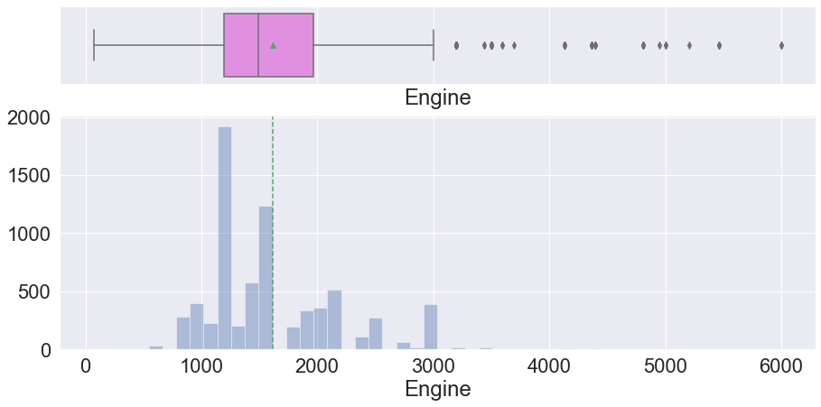

```python
histogram_boxplot(UCD['Engine'])
```

- The shape of distribution is difficult to determine
- Engine size may not be completely continuous and there may be other reasons why the data is shaped like this
- There are many outliers above 3000

The Engine's displacement volume is measured in CC. We have several outliers occuring above the 3000 mark. Lets take a look...

```python
UCD.loc[UCD['Engine'] >= 5000] # we'll start with over 5000
```

|  | Name | Location | Year | Kilometers_Driven | Fuel_Type | Transmission | Owner_Type | Mileage | Engine | Power | Seats | New_Price | Price |
| --- | --- | --- | --- | --- | --- | --- | --- | --- | --- | --- | --- | --- | --- |
| 152 | Mercedes-Benz | Kolkata | 2010 | 35277 | Petrol | Automatic | First | 7.81 | 5461.0 | 362.9 | 5.0 | NaN | 39000.0 |
| 4691 | Mercedes-Benz | Bangalore | 2014 | 3000 | Petrol | Automatic | Second | 12.00 | 5461.0 | 421.0 | 2.0 | NaN | 117000.0 |
| 4722 | Mercedes-Benz | Kolkata | 2010 | 35000 | Petrol | Automatic | First | 8.10 | 5461.0 | 387.3 | 2.0 | NaN | 38350.0 |
| 5088 | Jaguar | Coimbatore | 2011 | 43686 | Petrol | Automatic | First | 10.50 | 5000.0 | 503.0 | 4.0 | NaN | 65858.0 |
| 5521 | Bentley | Hyderabad | 2006 | 48000 | Petrol | Automatic | First | 8.60 | 5998.0 | 552.0 | 4.0 | NaN | 76700.0 |
| 5781 | Lamborghini | Delhi | 2011 | 6500 | Petrol | Automatic | Third | 6.40 | 5204.0 | 560.0 | 2.0 | NaN | 156000.0 |
| 5919 | Jaguar | Hyderabad | 2015 | 8000 | Petrol | Automatic | First | 12.50 | 5000.0 | 488.1 | 2.0 | NaN | 130000.0 |
| 6354 | Bentley | Bangalore | 2008 | 31200 | Petrol | Automatic | Second | 10.20 | 5998.0 | 616.0 | 5.0 | 487500.0 | NaN |

There are 8 vehicles with engine CC > 5000. They all appear to be high-end luxury/sports cars. This seems to make sense and these outliers should probably remain in the dataset. These vehicles probably have correlated high power as well.

**Power**

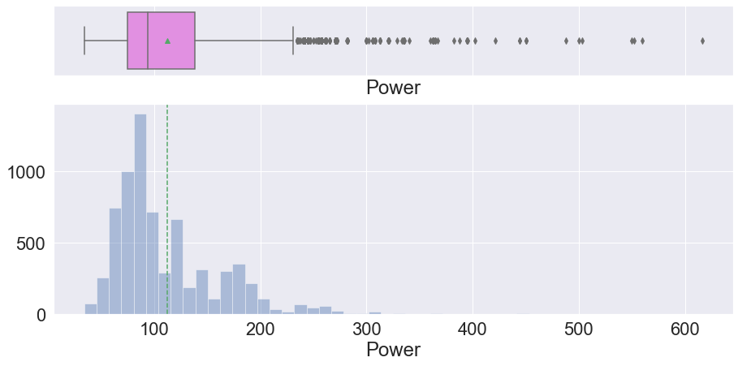

```python
histogram_boxplot(UCD['Power'])
```

- Power has a right skewed distribution. The mean is higher than the median.
- This means more used cars have lower power levels
- There are a number of outliers above 200+ bhp
- Lets look at the highest outliers...

```python
UCD.loc[UCD['Power'] >= 400] # we'll start with over 400
```

|  | Name | Location | Year | Kilometers_Driven | Fuel_Type | Transmission | Owner_Type | Mileage | Engine | Power | Seats | New_Price | Price |
| --- | --- | --- | --- | --- | --- | --- | --- | --- | --- | --- | --- | --- | --- |
| 70 | Porsche | Mumbai | 2008 | 73000 | Petrol | Automatic | First | 8.50 | 4806.0 | 500.0 | 5.0 | NaN | 18850.0 |
| 148 | Audi | Mumbai | 2013 | 23000 | Petrol | Automatic | First | 11.05 | 2894.0 | 444.0 | 4.0 | 166400.0 | 48100.0 |
| 2100 | Porsche | Mumbai | 2010 | 35000 | Petrol | Automatic | Second | 11.90 | 4806.0 | 550.0 | 5.0 | NaN | 41600.0 |
| 3341 | BMW | Kochi | 2010 | 50161 | Petrol | Automatic | First | 8.77 | 4395.0 | 402.0 | 5.0 | NaN | 33709.0 |
| 4061 | Audi | Mumbai | 2013 | 23312 | Petrol | Automatic | First | 11.05 | 2894.0 | 444.0 | 4.0 | 166400.0 | 52650.0 |
| 4627 | BMW | Kochi | 2010 | 65329 | Petrol | Automatic | First | 7.94 | 4395.0 | 450.0 | 4.0 | NaN | 26936.0 |
| 4691 | Mercedes-Benz | Bangalore | 2014 | 3000 | Petrol | Automatic | Second | 12.00 | 5461.0 | 421.0 | 2.0 | NaN | 117000.0 |
| 4821 | BMW | Mumbai | 2011 | 5900 | Petrol | Automatic | First | 7.94 | 4395.0 | 450.0 | 4.0 | NaN | 61750.0 |
| 5088 | Jaguar | Coimbatore | 2011 | 43686 | Petrol | Automatic | First | 10.50 | 5000.0 | 503.0 | 4.0 | NaN | 65858.0 |
| 5521 | Bentley | Hyderabad | 2006 | 48000 | Petrol | Automatic | First | 8.60 | 5998.0 | 552.0 | 4.0 | NaN | 76700.0 |
| 5781 | Lamborghini | Delhi | 2011 | 6500 | Petrol | Automatic | Third | 6.40 | 5204.0 | 560.0 | 2.0 | NaN | 156000.0 |
| 5919 | Jaguar | Hyderabad | 2015 | 8000 | Petrol | Automatic | First | 12.50 | 5000.0 | 488.1 | 2.0 | NaN | 130000.0 |
| 6354 | Bentley | Bangalore | 2008 | 31200 | Petrol | Automatic | Second | 10.20 | 5998.0 | 616.0 | 5.0 | 487500.0 | NaN |
| 7057 | BMW | Delhi | 2009 | 64000 | Petrol | Automatic | First | 7.94 | 4395.0 | 450.0 | 4.0 | NaN | NaN |

Again, the cars with power high enough to be considered outliers are luxury/sports vehicles that have similarly disproportionately large engines as well. This is logical and these outliers should remain in the dataset.

**Seats**

Since seats are non-continuous, we can do a value count..

```python
UCD.Seats.value_counts()
```

```
5.0     6047
7.0      796
8.0      170
4.0      119
6.0       38
2.0       18
10.0       8
9.0        3
0.0        1
Name: Seats, dtype: int64
```

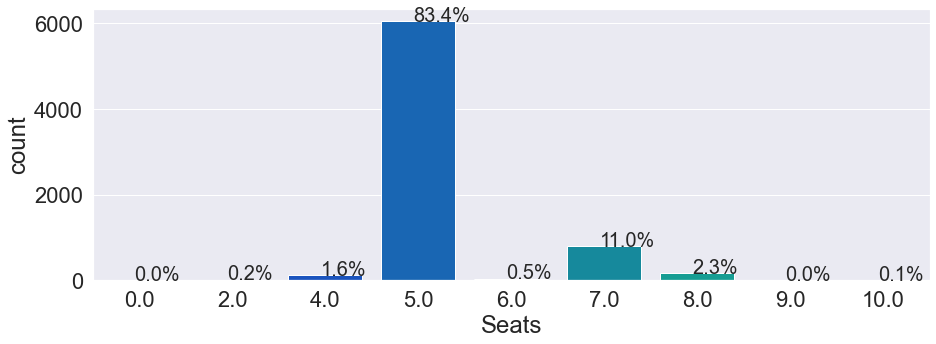

```python
plt.figure(figsize=(15,5))
ax = sns.countplot(UCD['Seats'], palette='winter')
perc_on_bar(ax,UCD['Seats'])
```

Since Seats is a non-continuous numerical value, with a small range, the histogram_boxplot combination will actually reveal less information than the above bar graph. From it we can see:

- A vast majority of cars have 5 seats
- The next highest frequency is 7 seats, this makes sense because bigger cars tend to have an additional row in the back
- No vehicles have 1 or 3 seats, again, based on our outside world knowledge of cars, this is logical

**Price**

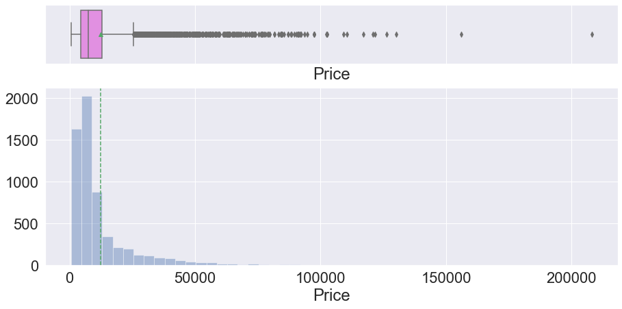

```python
histogram_boxplot(UCD['Price'])
```

- Price has a highly right skewed distribution. The mean is higher than the median.
- This means more used cars have relatively low resale value
- There are many outliers above about the 25k mark

```python
High_Price = UCD.loc[UCD['Price'] >= 100000].copy() #select and print the row of interest
High_Price
```

|  | Name | Location | Year | Kilometers_Driven | Fuel_Type | Transmission | Owner_Type | Mileage | Engine | Power | Seats | New_Price | Price |
| --- | --- | --- | --- | --- | --- | --- | --- | --- | --- | --- | --- | --- | --- |
| 1505 | Land | Kochi | 2019 | 26013 | Diesel | Automatic | First | 12.65 | 2993.0 | 255.00 | 5.0 | 180700.0 | 126191.0 |
| 1885 | Mercedes-Benz | Delhi | 2018 | 6000 | Diesel | Automatic | First | 11.00 | 2987.0 | 258.00 | 7.0 | 132600.0 | 102700.0 |
| 1974 | BMW | Coimbatore | 2018 | 28060 | Petrol | Automatic | First | 12.05 | 2979.0 | 320.00 | 5.0 | NaN | 121771.0 |
| 1984 | BMW | Bangalore | 2017 | 17465 | Petrol | Automatic | First | 12.05 | 2979.0 | 320.00 | 5.0 | NaN | 120900.0 |
| 2095 | Mercedes-Benz | Coimbatore | 2019 | 2526 | Petrol | Automatic | First | 19.00 | 2996.0 | 362.07 | 2.0 | 137800.0 | 109148.0 |
| 2319 | Mercedes-Benz | Coimbatore | 2019 | 9312 | Diesel | Automatic | First | 18.00 | 2987.0 | 258.00 | 5.0 | 120250.0 | 102440.0 |
| 2422 | Jaguar | Delhi | 2016 | 12000 | Diesel | Automatic | First | 10.50 | 2993.0 | 271.23 | 4.0 | NaN | 102700.0 |
| 4079 | Land | Hyderabad | 2017 | 25000 | Diesel | Automatic | First | 13.33 | 2993.0 | 255.00 | 5.0 | 299000.0 | 208000.0 |
| 4691 | Mercedes-Benz | Bangalore | 2014 | 3000 | Petrol | Automatic | Second | 12.00 | 5461.0 | 421.00 | 2.0 | NaN | 117000.0 |
| 5535 | BMW | Ahmedabad | 2015 | 97003 | Diesel | Automatic | First | 15.87 | 2993.0 | 308.43 | 5.0 | NaN | 110500.0 |
| 5781 | Lamborghini | Delhi | 2011 | 6500 | Petrol | Automatic | Third | 6.40 | 5204.0 | 560.00 | 2.0 | NaN | 156000.0 |
| 5919 | Jaguar | Hyderabad | 2015 | 8000 | Petrol | Automatic | First | 12.50 | 5000.0 | 488.10 | 2.0 | NaN | 130000.0 |

Once again, the high price corresponds to luxury/sports brand cars. The outliers seem reasonable considering the fact they are for higher end cars. They should not be removed from the data.

# Part 5: Dealing with Missing Values

First, lets remind ourselves which variables have missing values...

```python
UCD.isnull().sum()
```

```
Name                    0
Location                0
Year                    0
Kilometers_Driven       0
Fuel_Type               0
Transmission            0
Owner_Type              0
Mileage                 2
Engine                 46
Power                 175
Seats                  53
New_Price            6247
Price                1234
dtype: int64
```

We can see from above that 6 variables have missing values. These missing values need to be treated before we go ahead with the building of any models.

```python
UCD.describe().T #quick 5 point summary to remind ourselves of the data
```

|  | count | mean | std | min | 25% | 50% | 75% | max |
| --- | --- | --- | --- | --- | --- | --- | --- | --- |
| Year | 7253.0 | 2013.365366 | 3.254421 | 1996.0 | 2011.00 | 2014.00 | 2016.00 | 2019.00 |
| Kilometers_Driven | 7253.0 | 57806.880601 | 37498.477745 | 171.0 | 34000.00 | 53392.00 | 73000.00 | 775000.00 |
| Mileage | 7251.0 | 18.141580 | 4.562197 | 0.0 | 15.17 | 18.16 | 21.10 | 33.54 |
| Engine | 7207.0 | 1616.573470 | 595.285137 | 72.0 | 1198.00 | 1493.00 | 1968.00 | 5998.00 |
| Power | 7078.0 | 112.765214 | 53.493553 | 34.2 | 75.00 | 94.00 | 138.10 | 616.00 |
| Seats | 7200.0 | 5.279722 | 0.811660 | 0.0 | 5.00 | 5.00 | 5.00 | 10.00 |
| New_Price | 1006.0 | 29613.599404 | 36087.146725 | 5083.0 | 10250.50 | 15041.00 | 33855.25 | 487500.00 |
| Price | 6019.0 | 12323.308855 | 14544.292246 | 572.0 | 4550.00 | 7332.00 | 12935.00 | 208000.00 |

```python
UCD.median() # checks the median value of all the numerical columns
```

```
Year                  2014.00
Kilometers_Driven    53392.00
Mileage                 18.16
Engine                1493.00
Power                   94.00
Seats                    5.00
New_Price            15041.00
Price                 7332.00
dtype: float64
```

```python
UCD.mean() # checks the mean value for all the numerical columns
```

```
Year                  2013.365366
Kilometers_Driven    57806.880601
Mileage                 18.141580
Engine                1616.573470
Power                  112.765214
Seats                    5.279722
New_Price            29613.599404
Price                12323.308855
dtype: float64
```

**Mean or Median?**

If a variable is normally distributed, the mean, median, (and mode) are approximately the same. Therefore, replacing missing values by the mean and the median are equivalent.

If the variable is skewed, the mean is biased by the values at the far end of the distribution. Therefore, the median is a better representation of the majority of the values in the variable.

Since we know that only one variable (Mileage) has a mostly normal distributions and we know that several of the others (Price, Power, Engine, etc) are heavily skewed, we will replace missing values with the median.

Since our dataframe is a mix of categorical and numerical columns, we cannot replace the missing values with medians in one command since categorical variables do not have medians. So we will replace the numerical columns' missing values one at a time with the column median, and we would then replace categorical missing values with the most frequently recurring variable, however, no categorical variable column has missing values (ignoring New_Price for the time being)

**Mileage - Missing Values**

```python
UCD['Mileage'].isnull().sum() # checks to see how m any isnull values there are
```

```
2
```

```python
UCD['Mileage'].apply(type).value_counts() # counts the different data types and gives summation of each
```

```
<class 'float'>    7253
Name: Mileage, dtype: int64
```

Since Mileage only has 2 missing values (See above), lets take a look at the entire row where the two missing values are located.

```python
UCD.loc[UCD['Mileage'].isnull()]
```

|  | Name | Location | Year | Kilometers_Driven | Fuel_Type | Transmission | Owner_Type | Mileage | Engine | Power | Seats | New_Price | Price |
| --- | --- | --- | --- | --- | --- | --- | --- | --- | --- | --- | --- | --- | --- |
| 4446 | Mahindra | Chennai | 2016 | 50000 | Electric | Automatic | First | NaN | 72.0 | 41.0 | 5.0 | 17654.0 | 16900.0 |
| 4904 | Toyota | Mumbai | 2011 | 44000 | Electric | Automatic | First | NaN | 1798.0 | 73.0 | 5.0 | NaN | 16575.0 |

By checking the entire row, we discover two important things: first, the other values in the row are mostly complete; second, both Fuel_Types = Electric. Since the rest of the rows are mostly complete, dropping the entire rows is not a good option. COULD fill the two missing values with the median or mean of Mileage, but since they are Electric cars, lets first look at the mean average of mileage for all electric cars...

```python
UCD['Fuel_Type'].value_counts()
```

```
Diesel      3852
Petrol      3325
CNG           62
LPG           12
Electric       2
Name: Fuel_Type, dtype: int64
```

```python
UCD.loc[UCD['Fuel_Type'] == 'Electric']
```

|  | Name | Location | Year | Kilometers_Driven | Fuel_Type | Transmission | Owner_Type | Mileage | Engine | Power | Seats | New_Price | Price |
| --- | --- | --- | --- | --- | --- | --- | --- | --- | --- | --- | --- | --- | --- |
| 4446 | Mahindra | Chennai | 2016 | 50000 | Electric | Automatic | First | NaN | 72.0 | 41.0 | 5.0 | 17654.0 | 16900.0 |
| 4904 | Toyota | Mumbai | 2011 | 44000 | Electric | Automatic | First | NaN | 1798.0 | 73.0 | 5.0 | NaN | 16575.0 |

Interestingly enough, the only instances of used cars with Fuel_Type = 'Electric' are the same two instances where mileage is missing. Using our outside knowledge of motor engines, we know that electic engines do not run on gasoline or other liquid fuel so kmpl or km/kg are not good measures. Normally, electric engines are measured by range in km per battery charge, or some similar measure. This, coupled with the fact that there are only 2 instances of electric cars out of a sample of 7253 used cars, means they do not fit this model very well and so we shall just drop these two rows.

**Note of Caution:**

By dropping the only two rows that contained Fuel_Type = 'Electric', this model will not accurately predict prices of used cars for cars of this fuel type going forward. Management needs to know that they should NOT use this model to try and predict prices for used electric cars in the future. However, due to the incredible small number of Electric cars in this sample, there was a bigger danger in imputing the Mileage of electric cars and including them in the model, and assuming this model would be applicable to used electric cars.

```python
UCD.drop([4446, 4904], axis=0, inplace=True) # this will drop the two rows where Fuel_Type = 'Electric' and Mileage = NaN
UCD.reset_index(inplace=True) #this will reset the index so there are no gaps where the two rows were removed
```

```python
UCD.shape # there should now be 7251 rows
```

```
(7251, 14)
```

```python
UCD['Fuel_Type'].value_counts() # quickly check to see if 'Electric' has been removed from Fuel_Type
```

```
Diesel    3852
Petrol    3325
CNG         62
LPG         12
Name: Fuel_Type, dtype: int64
```

While we deleted all the NaN values in the Mileage category, there could still be instances of missing values if there were inputs of 0kmpl or 0.0km/kg (or a combination thereof) in the original data. We should look for these instances as well....

```python
counter_mileage0 = 0

for index in range(0, len(UCD)):
    if UCD['Mileage'].loc[index] == 0:
        counter_mileage0 = counter_mileage0 + 1

print('There are still', counter_mileage0, 'missing Mileage values')
```

```
There are still 81 missing Mileage values
```

Lets get a look at the data where Mileage = 0

```python
UCD.loc[UCD['Mileage'] == 0]
```

|  | index | Name | Location | Year | Kilometers_Driven | Fuel_Type | Transmission | Owner_Type | Mileage | Engine | Power | Seats | New_Price | Price |
| --- | --- | --- | --- | --- | --- | --- | --- | --- | --- | --- | --- | --- | --- | --- |
| 14 | 14 | Land | Pune | 2012 | 85000 | Diesel | Automatic | Second | 0.0 | 2179.0 | 115.0 | 5.0 | NaN | 22750.0 |
| 67 | 67 | Mercedes-Benz | Coimbatore | 2019 | 15369 | Diesel | Automatic | First | 0.0 | 1950.0 | 194.0 | 5.0 | 63882.0 | 46371.0 |
| 79 | 79 | Hyundai | Hyderabad | 2005 | 87591 | Petrol | Manual | First | 0.0 | 1086.0 | NaN | 5.0 | NaN | 1690.0 |
| 194 | 194 | Honda | Ahmedabad | 2007 | 60006 | Petrol | Manual | First | 0.0 | NaN | NaN | NaN | NaN | 3835.0 |
| 229 | 229 | Ford | Bangalore | 2015 | 70436 | Diesel | Manual | First | 0.0 | 1498.0 | 99.0 | NaN | NaN | 4680.0 |
| ... | ... | ... | ... | ... | ... | ... | ... | ... | ... | ... | ... | ... | ... | ... |
| 6631 | 6633 | Mahindra | Kolkata | 2016 | 27000 | Diesel | Manual | First | 0.0 | NaN | NaN | NaN | NaN | NaN |
| 6695 | 6697 | Hyundai | Jaipur | 2007 | 85000 | Petrol | Manual | Second | 0.0 | 1086.0 | NaN | 5.0 | NaN | NaN |
| 6855 | 6857 | Land | Mumbai | 2011 | 87000 | Diesel | Automatic | First | 0.0 | 2179.0 | 115.0 | 5.0 | NaN | NaN |
| 6955 | 6957 | Honda | Kochi | 2019 | 11574 | Petrol | Manual | First | 0.0 | 1199.0 | 88.7 | NaN | NaN | NaN |
| 7224 | 7226 | Hyundai | Ahmedabad | 2014 | 41000 | Petrol | Manual | First | 0.0 | 1086.0 | 62.0 | 5.0 | NaN | NaN |

81 rows × 14 columns

We will now change all of the 0 values to NaN. This will allow us to replace NaN values with the median much easier afterwards.

```python
UCD['Mileage'].replace(0, np.nan, inplace=True) # changes the 0s to NaN
```

```python
UCD['Mileage'] = UCD['Mileage'].fillna(UCD['Mileage'].median()) # repleaces NaN values with the column's median of 18.20
```

```python
UCD.loc[[14, 67, 79], :] # Spot check.. these three rows were listed as 0 above, they should now be 18.20
```

|  | index | Name | Location | Year | Kilometers_Driven | Fuel_Type | Transmission | Owner_Type | Mileage | Engine | Power | Seats | New_Price | Price |
| --- | --- | --- | --- | --- | --- | --- | --- | --- | --- | --- | --- | --- | --- | --- |
| 14 | 14 | Land | Pune | 2012 | 85000 | Diesel | Automatic | Second | 18.2 | 2179.0 | 115.0 | 5.0 | NaN | 22750.0 |
| 67 | 67 | Mercedes-Benz | Coimbatore | 2019 | 15369 | Diesel | Automatic | First | 18.2 | 1950.0 | 194.0 | 5.0 | 63882.0 | 46371.0 |
| 79 | 79 | Hyundai | Hyderabad | 2005 | 87591 | Petrol | Manual | First | 18.2 | 1086.0 | NaN | 5.0 | NaN | 1690.0 |

**Engine - Missing Values**

```python
UCD['Engine'].isnull().sum() # checks to see how m any isnull values there are
```

```
46
```

We know there are 46 instances where data is missing, but like with Mileage, lets also check to see if there are any values equal to zero...

```python
counter_engine0 = 0

for index in range(0, len(UCD)):
    if UCD['Engine'].loc[index] == 0:
        counter_engine0 = counter_engine0 + 1

print('There are', counter_engine0, 'Engine values equal to 0')
```

```
There are 0 Engine values equal to 0
```

It makes sense that there are no entries where engine equals zero, since this would not be possible for a functioning car. Therefore, there are only excluded values and no values that were inputed by mistake that we can see. We can now convert the NaN values to the column median.

```python
UCDE = UCD.copy() # making a copy just to ensure that converting NaN to column median is the best choice
```

```python
np.median(UCDE.Engine)
```

```
nan
```

```python
UCDE['Engine'] = UCDE['Engine'].fillna(UCDE['Engine'].median()) # converts missing values to column median
```

```python
UCDE.isnull().sum()
```

```
index                   0
Name                    0
Location                0
Year                    0
Kilometers_Driven       0
Fuel_Type               0
Transmission            0
Owner_Type              0
Mileage                 0
Engine                  0
Power                 175
Seats                  53
New_Price            6246
Price                1234
dtype: int64
```

```python
UCDBE = UCD.copy() #lets copy the data again so we can try a different method...
```

Let's try converting missing values to the engine median of a group of similarly named automobiles...

```python
UCDBE.groupby('Name')['Engine'].median()
```

```
Name
Audi             1968.0
BMW              1995.0
Bentley          5998.0
Chevrolet        1199.0
Datsun           1198.0
Fiat             1248.0
Force            2200.0
Ford             1498.0
Hindustan        1742.0
Honda            1497.0
Hyundai          1197.0
Isuzu            2499.0
Jaguar           2179.0
Jeep             1956.0
Lamborghini      5204.0
Land             2179.0
Mahindra         2179.0
Maruti           1197.0
Mercedes-Benz    2143.0
Mini             1598.0
Mitsubishi       2477.0
Nissan           1461.0
OpelCorsa        1389.0
Porsche          2967.0
Renault          1461.0
Skoda            1798.0
Smart             799.0
Tata             1248.0
Toyota           2494.0
Volkswagen       1498.0
Volvo            1985.0
Name: Engine, dtype: float64
```

We can see there is quite the range of different engine values depending on car type. Instead of replacing the missing values in the Engine column with the column median, lets replace the missing values with the median of the corresponding car Name.

```python
UCDBE['Engine'] = UCDBE['Engine'].fillna(UCDBE.groupby('Name')['Engine'].transform('median'))
```

```python
UCDBE.isnull().sum() #checks to see if all Engine NaNs have been replaced
```

```
index                   0
Name                    0
Location                0
Year                    0
Kilometers_Driven       0
Fuel_Type               0
Transmission            0
Owner_Type              0
Mileage                 0
Engine                  0
Power                 175
Seats                  53
New_Price            6246
Price                1234
dtype: int64
```

One way to check to see which method is superior, is to compare the correlation between the variable and Price (independent variable). We will choose the one with the higher value since it will explain more variation in the price data.

```python
UCD.corr() # before NaNs were replaced..0.658855
```

|  | index | Year | Kilometers_Driven | Mileage | Engine | Power | Seats | New_Price | Price |
| --- | --- | --- | --- | --- | --- | --- | --- | --- | --- |
| index | 1.000000 | 0.005592 | -0.002536 | 0.013662 | -0.014499 | -0.021534 | -0.006673 | -0.064992 | -0.020374 |
| Year | 0.005592 | 1.000000 | -0.449596 | 0.295442 | -0.054402 | 0.013504 | 0.008220 | -0.058784 | 0.305355 |
| Kilometers_Driven | -0.002536 | -0.449596 | 1.000000 | -0.142581 | 0.158644 | 0.002275 | 0.211914 | -0.008109 | -0.168548 |
| Mileage | 0.013662 | 0.295442 | -0.142581 | 1.000000 | -0.639729 | -0.548936 | -0.346384 | -0.376979 | -0.329960 |
| Engine | -0.014499 | -0.054402 | 0.158644 | -0.639729 | 1.000000 | 0.859868 | 0.399348 | 0.737783 | 0.658855 |
| Power | -0.021534 | 0.013504 | 0.002275 | -0.548936 | 0.859868 | 1.000000 | 0.095819 | 0.878126 | 0.772837 |
| Seats | -0.006673 | 0.008220 | 0.211914 | -0.346384 | 0.399348 | 0.095819 | 1.000000 | -0.019585 | 0.052262 |
| New_Price | -0.064992 | -0.058784 | -0.008109 | -0.376979 | 0.737783 | 0.878126 | -0.019585 | 1.000000 | 0.871899 |
| Price | -0.020374 | 0.305355 | -0.168548 | -0.329960 | 0.658855 | 0.772837 | 0.052262 | 0.871899 | 1.000000 |